# Python-Jupyter (+R) basics tutorial for DM 2017 course

This notebook contains some information and examples for getting started with Jupyter and Python.

- To begin, I recommend to install Anaconda (links are in the courses page), it has all the necessary modules already there. If something is not, then using **conda install package-name** will usually do the trick.
- After installing Anaconda type **jupyter notebook** from your terminal and let the fun begin.
- To get the documentation write ? before the function or just press SHIFT+TAB on the function name.
- Basic commands for pandas: https://courses.cs.ut.ee/MTAT.03.183/2017_spring/uploads/Main/pandas-cheat-sheet.pdf - really useful and has a lot of what you will need during the course.
- Cool Jupyter Notebook tricks: https://www.dataquest.io/blog/jupyter-notebook-tips-tricks-shortcuts/.

Now we can start with the tutorial. First thing is to import the necessary modules.

```python
# we will use the pandas module because it allows us to work with R-like dataframes
import pandas as pd

# often we need some functions from numpy as well
import numpy as np

# the next two lines will force jypyter to output all results from a cell (by default only the last one is shown)
# using semicolon (;) in the end of a line will force that line not to output the result
from IPython.core.interactiveshell import InteractiveShell
InteractiveShell.ast_node_interactivity = "all"
```

# 1. Data manipulation with pandas dataframes

Pandas dataframe is a convenient structure to work with data and has a lot of useful functionality for data analysis. If you are already familiar with R dataframes, then this is something really-really similar.

## 1.1 Creating a dataframe

```python
# You can create a dataframe from scratch if you want to
# (although probably rarely need it during this course)
# you have to specify column names and data
df = pd.DataFrame({ 'A' : 1.,
                    'B' : pd.Timestamp('20130102'),
                    'C' : pd.Series([1,2,3,4],dtype='int32'), # you can be very specific about the data types
                    'D' : [4,2,3,4], # if you are not, pandas will try to guess
                    'E' : pd.Categorical(["test","train","test","train"]),
                    'F' : ["test", "train", "test", "train"],
                    'G' : 'foo' })
```

## 1.2 Information about a dataframe

```python
# you can see information about the data in different ways
df.head() # first rows
df.tail(2) # last rows
df.shape # dimensions
df.describe() # summary statistics
```

|  | A | B | C | D | E | F | G |
| --- | --- | --- | --- | --- | --- | --- | --- |
| 0 | 1.0 | 2013-01-02 | 1 | 4 | test | test | foo |
| 1 | 1.0 | 2013-01-02 | 2 | 2 | train | train | foo |
| 2 | 1.0 | 2013-01-02 | 3 | 3 | test | test | foo |
| 3 | 1.0 | 2013-01-02 | 4 | 4 | train | train | foo |

|  | A | B | C | D | E | F | G |
| --- | --- | --- | --- | --- | --- | --- | --- |
| 2 | 1.0 | 2013-01-02 | 3 | 3 | test | test | foo |
| 3 | 1.0 | 2013-01-02 | 4 | 4 | train | train | foo |

```
(4, 7)
```

|  | A | C | D |
| --- | --- | --- | --- |
| count | 4.0 | 4.000000 | 4.000000 |
| mean | 1.0 | 2.500000 | 3.250000 |
| std | 0.0 | 1.290994 | 0.957427 |
| min | 1.0 | 1.000000 | 2.000000 |
| 25% | 1.0 | 1.750000 | 2.750000 |
| 50% | 1.0 | 2.500000 | 3.500000 |
| 75% | 1.0 | 3.250000 | 4.000000 |
| max | 1.0 | 4.000000 | 4.000000 |

## 1.3 Series

```python
# we can also create series - all dataframe columns are also series
s = pd.Series([1,5,2,6,4,5])

# and we can count different values in there
s.value_counts()

# as already said, we can do this also on the columns of dataframes
# (these two commands are identical)
df["D"].value_counts()
df.D.value_counts()
```

```
5    2
6    1
4    1
2    1
1    1
dtype: int64
```

```
4    2
3    1
2    1
Name: D, dtype: int64
```

```
4    2
3    1
2    1
Name: D, dtype: int64
```

## 1.4 Reading a dataframe from file

```python
# usually we read the dataset from some file (for example csv)
irisdf = pd.read_csv("iris.csv", header=None)

# we can assign (new) column names
irisdf.columns = ["sepal_length", "sepal_width", "petal_length", "petal_width", "species"]

# see the data
irisdf.head()

# data size
irisdf.shape

# ask for specific statistic of a column
irisdf.sepal_length.mean()

# or of all columns
irisdf.mean()
```

|  | sepal_length | sepal_width | petal_length | petal_width | species |
| --- | --- | --- | --- | --- | --- |
| 0 | 5.1 | 3.5 | 1.4 | 0.2 | Iris-setosa |
| 1 | 4.9 | 3.0 | 1.4 | 0.2 | Iris-setosa |
| 2 | 4.7 | 3.2 | 1.3 | 0.2 | Iris-setosa |
| 3 | 4.6 | 3.1 | 1.5 | 0.2 | Iris-setosa |
| 4 | 5.0 | 3.6 | 1.4 | 0.2 | Iris-setosa |

```
(150, 5)
```

```
5.843333333333335
```

```
sepal_length    5.843333
sepal_width     3.054000
petal_length    3.777181
petal_width     1.212162
dtype: float64
```

## 1.5 Working with NA's

```python
# how many NA elements in every column
irisdf.isnull().sum()
```

```
sepal_length    0
sepal_width     0
petal_length    1
petal_width     2
species         0
dtype: int64
```

```python
# remove rows that have NA's
irisdf = irisdf.dropna()

# now the shape is
irisdf.shape
```

```
(147, 5)
```

```python
# you can also write data to a file
irisdf.to_csv("iris_no_na.csv")
```

## 1.6 Subsetting dataframes

```python
# selecting only some column/columns (head() command is just for convenient printing)
irisdf["sepal_length"].head()
irisdf[["sepal_length", "sepal_width"]].head()
```

```
0    5.1
1    4.9
2    4.7
3    4.6
4    5.0
Name: sepal_length, dtype: float64
```

|  | sepal_length | sepal_width |
| --- | --- | --- |
| 0 | 5.1 | 3.5 |
| 1 | 4.9 | 3.0 |
| 2 | 4.7 | 3.2 |
| 3 | 4.6 | 3.1 |
| 4 | 5.0 | 3.6 |

```python
# selecting rows
irisdf[irisdf["sepal_width"] > 4].head()
irisdf[(irisdf["sepal_width"] > 4) & (irisdf["petal_length"] > 1.4)].head()
irisdf[(irisdf["sepal_width"] > 4) | ((irisdf["species"] == "Iris-versicolor") & (irisdf["petal_length"] > 1.4))].head()
```

|  | sepal_length | sepal_width | petal_length | petal_width | species |
| --- | --- | --- | --- | --- | --- |
| 15 | 5.7 | 4.4 | 1.5 | 0.4 | Iris-setosa |
| 32 | 5.2 | 4.1 | 1.5 | 0.1 | Iris-setosa |
| 33 | 5.5 | 4.2 | 1.4 | 0.2 | Iris-setosa |

|  | sepal_length | sepal_width | petal_length | petal_width | species |
| --- | --- | --- | --- | --- | --- |
| 15 | 5.7 | 4.4 | 1.5 | 0.4 | Iris-setosa |
| 32 | 5.2 | 4.1 | 1.5 | 0.1 | Iris-setosa |

|  | sepal_length | sepal_width | petal_length | petal_width | species |
| --- | --- | --- | --- | --- | --- |
| 15 | 5.7 | 4.4 | 1.5 | 0.4 | Iris-setosa |
| 32 | 5.2 | 4.1 | 1.5 | 0.1 | Iris-setosa |
| 33 | 5.5 | 4.2 | 1.4 | 0.2 | Iris-setosa |
| 50 | 7.0 | 3.2 | 4.7 | 1.4 | Iris-versicolor |
| 51 | 6.4 | 3.2 | 4.5 | 1.5 | Iris-versicolor |

## 1.7 Adding new columns

```python
# adding a new columns
irisdf["petal_sum"] = irisdf["petal_length"] + irisdf["petal_width"]
irisdf["petal_max"] = irisdf.apply(lambda row: max([row["petal_length"], row["petal_width"]]), axis=1)
irisdf["flower"] = irisdf.apply(lambda row: "small_flower" if row["sepal_length"] < 5 else "big_flower", axis=1)
irisdf.head()
irisdf.flower.value_counts()
```

[output not shown]

```
big_flower      128
small_flower     19
Name: flower, dtype: int64
```

# 2. Plotting

```python
import matplotlib.pyplot as plt

# allows to output plots in the notebook
%matplotlib inline

# makes inline plots to have better quality (can replace svg with retina as well)
%config InlineBackend.figure_format = 'svg'

# can change the default style of plots - google for more choices
plt.style.use("ggplot")
```

## 2.1 Example 1 - scatterplot with outliers

```python
# usual plot
irisdf.plot(x="sepal_length", y="sepal_width", kind="scatter")

# calculating IQR (difference between 75% and 25% quantile)
IQR = irisdf["sepal_width"].quantile(0.75) - irisdf["sepal_width"].quantile(0.25) # interquartile range

# filtering out outliers (rows with "extreme" values - not all of them are actually outliers)
outliers = irisdf[irisdf["sepal_width"] > irisdf["sepal_width"].quantile(0.75) + 1.5*IQR]

# remove outliers from other data
usual = irisdf.drop(outliers.index)

# plot outliers with different color
ax = usual.plot(x="sepal_length", y="sepal_width", kind="scatter")
outliers.plot(x="sepal_length", y="sepal_width", kind="scatter", c="red", ax=ax)
ax.set_title("Cool scatterplot")
ax.set_ylabel("I can change this")
ax.set_xlim([0,10]);
```

[figure not shown]

## 2.2 Histogram

```python
irisdf["sepal_length"].hist();
```

[figure not shown]

## 2.3 Barplot for categorical values

```python
irisdf.species.value_counts().plot(kind="bar");
```

[figure not shown]

## 2.4 Grouped barplot

```python
irisdf.groupby(["species", "flower"])["sepal_length"].count().unstack().plot(kind="bar");
```

[figure not shown]

## 2.5 Seaborn module

Seaborn is a plotting module for Python that allows to do some cool and quite complicated plots easily. It is not in the default installation of Anaconda so you need to install it (**conda install seaborn**).

```python
import seaborn as sns

sns.pairplot(irisdf[["sepal_length", "petal_length", "species"]], hue="species");
```

[figure not shown]

## 2.6 Using R in a Python Jupyter notebook

There is some functionality that is present in R and not in Python. Also plotting capabilities of R are sometimes more flexible and easier to use. Because of that it is good to for example do some initial data processing in Python and then plot the results in R. In Jupyter notebook we can do it in a one notebook in the following way.

Before running these commands, you need to install the necessary things. Follow the instructions under steps 20 and 21 in here: https://www.dataquest.io/blog/jupyter-notebook-tips-tricks-shortcuts/. The installation might not go too smoothly (I had some issues) but after you get it working, it is very convenient.

```python
# fist load the necessary things to work with R in Python Jupyter notebook

%load_ext rpy2.ipython
%R require(ggplot2)
#%Rdevice svg <- you can try to do smth like this to get good quality R imgs, but it might not work
```

```
The rpy2.ipython extension is already loaded. To reload it, use:
  %reload_ext rpy2.ipython
```

```
array([1], dtype=int32)
```

- To write R code in a cell, you have to start it with %%R command - rmagic command.
- If you want to give some existing data to R, use -i command, you can also send output from R.
- Other commands are there to make the plots look nice - you can experiment with them, remove them etc.
- Read more about the possibilities from here: https://ipython.org/ipython-doc/2/config/extensions/rmagic.html.

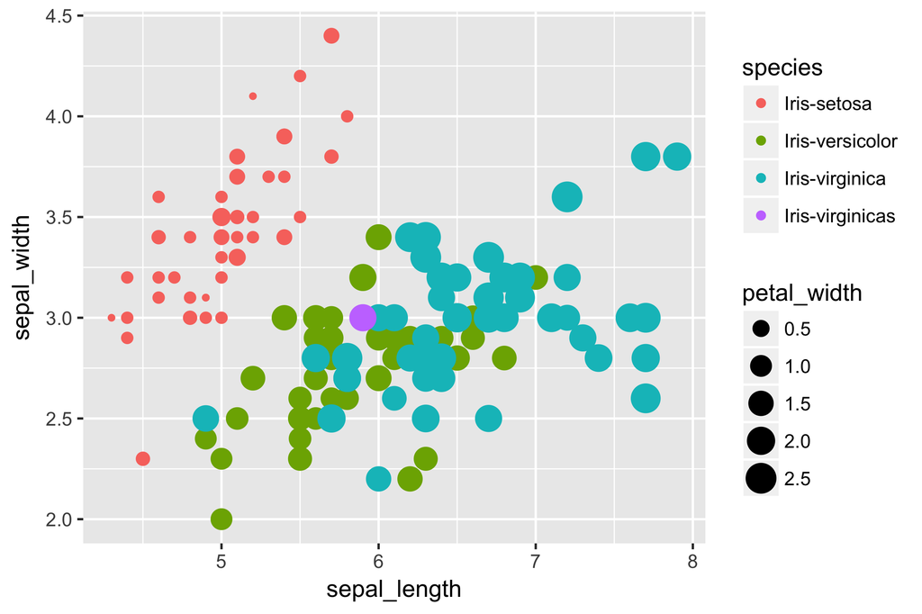

```python
%%R -i irisdf -w 150 -h 100 -u mm -r 400

ggplot(irisdf, aes(x = sepal_length, y = sepal_width,color = species, size = petal_width)) + geom_point()
```

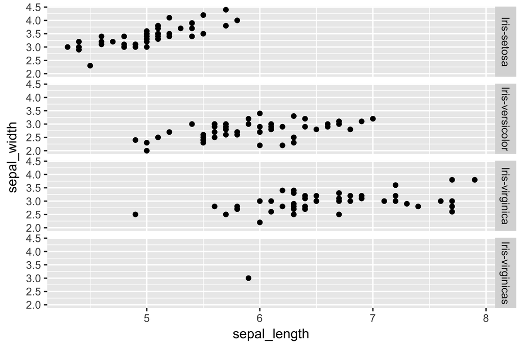

```python
%%R -i irisdf -w 150 -h 100 -u mm -r 400

ggplot(irisdf, aes(x = sepal_length, y = sepal_width))+ geom_point() + facet_grid(species~.)
```